# Estatísticas descritivas no R e alguns gráficos

Cristiano de Carvalho Santos - Departamento de Estatística da UFMG

## Transformação no banco de dados

Algumas vezes temos a necessidade de realizar alguma tranformação em uma ou mais variáveis do banco de dados.

- Isto pode ser feito de diversas formas, uma delas é utilizando a função *transform*.

Veja alguns exemplos:

```r
# Manipulacao de banco de dados
milsa <- read.table("http://www.leg.ufpr.br/~paulojus/dados/milsa.dat", head = T)

# Podemos visualizar o banco de dados com View(milsa)

# Podemo ver algumas caracteristicas do banco de dados com:
mode(milsa)
```

```
## [1] "list"
```

```r
str(milsa)
```

```
## 'data.frame':    36 obs. of  8 variables:
##  $ funcionario: int  1 2 3 4 5 6 7 8 9 10 ...
##  $ civil      : int  1 2 2 1 1 2 1 1 2 1 ...
##  $ instrucao  : int  1 1 1 2 1 1 1 1 2 2 ...
##  $ filhos     : int  NA 1 2 NA NA 0 NA NA 1 NA ...
##  $ salario    : num  4 4.56 5.25 5.73 6.26 6.66 6.86 7.39 7.59 7.44 ...
##  $ ano        : int  26 32 36 20 40 28 41 43 34 23 ...
##  $ mes        : int  3 10 5 10 7 0 0 4 10 6 ...
##  $ regiao     : int  1 2 2 3 3 1 1 2 2 3 ...
```

```r
names(milsa)
```

```
## [1] "funcionario" "civil"       "instrucao"   "filhos"      "salario"
## [6] "ano"         "mes"         "regiao"
```

```r
# veja o help da função digitando: ?transform

## Transformando um banco de dados
milsa <- transform(milsa, civil = factor(civil, label = c("solteiro", "casado"), levels = 1:2),
                   instrucao = factor(instrucao, label = c("1oGrau",   "2oGrau", "Superior"),
                                      lev = 1:3, ord = T),
                   regiao = factor(regiao, label = c("capital", "interior", "outro"),
                                   lev = c(2, 1, 3)))

milsa <- transform(milsa, idade = ano + mes/12)
milsa
```

```
##    funcionario    civil instrucao filhos salario ano mes   regiao    idade
## 1            1 solteiro    1oGrau     NA    4.00  26   3 interior 26.25000
## 2            2   casado    1oGrau      1    4.56  32  10  capital 32.83333
## 3            3   casado    1oGrau      2    5.25  36   5  capital 36.41667
## 4            4 solteiro    2oGrau     NA    5.73  20  10    outro 20.83333
## 5            5 solteiro    1oGrau     NA    6.26  40   7    outro 40.58333
## 6            6   casado    1oGrau      0    6.66  28   0 interior 28.00000
## 7            7 solteiro    1oGrau     NA    6.86  41   0 interior 41.00000
## 8            8 solteiro    1oGrau     NA    7.39  43   4  capital 43.33333
## 9            9   casado    2oGrau      1    7.59  34  10  capital 34.83333
## 10          10 solteiro    2oGrau     NA    7.44  23   6    outro 23.50000
## 11          11   casado    2oGrau      2    8.12  33   6 interior 33.50000
## 12          12 solteiro    1oGrau     NA    8.46  27  11  capital 27.91667
## 13          13 solteiro    2oGrau     NA    8.74  37   5    outro 37.41667
## 14          14   casado    1oGrau      3    8.95  44   2    outro 44.16667
```

[output cut: 22 more lines]

## Função attach

- A função attach é utilizada para fixar o data.frame a ser utilizado;
- Podemos fazer referência à variável apenas pelo seu nome, sem necessidade de usar o símbolo $.
- Após terminar de trabalhar com o data.frame fixado utilize o comando detach (nome do dataset) para desabilitar o comando attach.

```r
attach(milsa)
civil
```

```
##  [1] solteiro casado   casado   solteiro solteiro casado   solteiro solteiro
##  [9] casado   solteiro casado   solteiro solteiro casado   casado   solteiro
## [17] casado   casado   solteiro solteiro casado   solteiro solteiro casado
## [25] casado   casado   solteiro casado   casado   casado   solteiro casado
## [33] casado   solteiro casado   casado
## Levels: solteiro casado
```

```r
detach(milsa)
```

## Quais ferramentas utilizamos na análise descritiva de um banco de dados?

- Tabelas de frequências
- Gráficos
- Medidas resumo

## Análise descritiva - variáveis qualitativas

Utilizamos os mesmos tipos de gráficos para variáveis qualitativas e quantitativas? **NÃO!!!**

$~$

### Construção de tabelas de frequências:

- As funções **table** e ftable podem ser usadas para construir tabelas de frequências;
- prop.table pode ser usada para calcular frequências relativas;
- round pode ser usada para determinar o número de casas decimais na exibição dos números;
- margin.table é utilizada para calcular as somas marginais em tabelas de frequências com mais de uma variável.

```r
attach(milsa)
t1 <- table(civil)
t1
```

```
## civil
## solteiro   casado
##       16       20
```

```r
prop.table(t1)
```

```
## civil
##  solteiro    casado
## 0.4444444 0.5555556
```

```r
round(prop.table(t1), 2)
```

```
## civil
## solteiro   casado
##     0.44     0.56
```

```r
detach(milsa)
```

Algumas vezes não desejamos utilizar a função attach

```r
## Tabelas de contingencia - sem usar o attach
t2 <- table(milsa[, c(2, 3)])
t2
```

```
##           instrucao
## civil      1oGrau 2oGrau Superior
##   solteiro      7      6        3
##   casado        5     12        3
```

```r
class(t2)
```

```
## [1] "table"
```

```r
is.matrix(t2)
```

```
## [1] TRUE
```

```r
dimnames(t2)
```

```
## $civil
## [1] "solteiro" "casado"
##
## $instrucao
## [1] "1oGrau"   "2oGrau"   "Superior"
```

```r
(t2 <- table(milsa[, c(2, 3)], dnn = c("Estado Civil", "Nivel de Instrucao")))
```

```
##             Nivel de Instrucao
## Estado Civil 1oGrau 2oGrau Superior
##     solteiro      7      6        3
##     casado        5     12        3
```

```r
# Distribuicao marginal
margin.table(t2, mar = 1)
```

```
## Estado Civil
## solteiro   casado
##       16       20
```

```r
margin.table(t2, mar = 2)
```

```
## Nivel de Instrucao
##   1oGrau   2oGrau Superior
##       12       18        6
```

```r
addmargins(t2, mar=1)
```

```
##             Nivel de Instrucao
## Estado Civil 1oGrau 2oGrau Superior
##     solteiro      7      6        3
##     casado        5     12        3
##     Sum          12     18        6
```

```r
## Tabelas para 3 variaveis e uso do with
t3 <- with(milsa, table(civil, instrucao, regiao))
t3
```

```
## , , regiao = capital
##
##           instrucao
## civil      1oGrau 2oGrau Superior
##   solteiro      2      1        1
##   casado        2      4        1
##
## , , regiao = interior
##
##           instrucao
## civil      1oGrau 2oGrau Superior
##   solteiro      2      1        1
##   casado        1      6        1
##
## , , regiao = outro
##
##           instrucao
## civil      1oGrau 2oGrau Superior
##   solteiro      3      4        1
##   casado        2      2        1
```

```r
# Eh possivel mudar a visualizacao da tabela com o col.vars
with(milsa, ftable(civil, instrucao, regiao, dnn = c("Estado Civil:",
                 "Nivel de Instrucao", "Procedencia:"), col.vars = c(1, 3)))
```

```
##                    Estado Civil: solteiro                 casado
##                    Procedencia:   capital interior outro capital interior outro
## Nivel de Instrucao
## 1oGrau                                  2        2     3       2        1     2
## 2oGrau                                  1        1     4       4        6     2
## Superior                                1        1     1       1        1     1
```

```r
## Frequencias relativas
prop.table(t3)
```

```
## , , regiao = capital
##
##           instrucao
## civil          1oGrau     2oGrau   Superior
##   solteiro 0.05555556 0.02777778 0.02777778
##   casado   0.05555556 0.11111111 0.02777778
##
## , , regiao = interior
##
##           instrucao
## civil          1oGrau     2oGrau   Superior
##   solteiro 0.05555556 0.02777778 0.02777778
##   casado   0.02777778 0.16666667 0.02777778
##
## , , regiao = outro
##
##           instrucao
## civil          1oGrau     2oGrau   Superior
##   solteiro 0.08333333 0.11111111 0.02777778
##   casado   0.05555556 0.05555556 0.02777778
```

```r
prop.table(t3, margin = 1)
```

```
## , , regiao = capital
##
##           instrucao
## civil      1oGrau 2oGrau Superior
##   solteiro 0.1250 0.0625   0.0625
##   casado   0.1000 0.2000   0.0500
##
## , , regiao = interior
##
##           instrucao
## civil      1oGrau 2oGrau Superior
##   solteiro 0.1250 0.0625   0.0625
##   casado   0.0500 0.3000   0.0500
##
## , , regiao = outro
##
##           instrucao
## civil      1oGrau 2oGrau Superior
##   solteiro 0.1875 0.2500   0.0625
##   casado   0.1000 0.1000   0.0500
```

### Construção de gráficos de frequências:

- barplot: função para gráfico de barras;
- pie: função para gráfico de pizza.

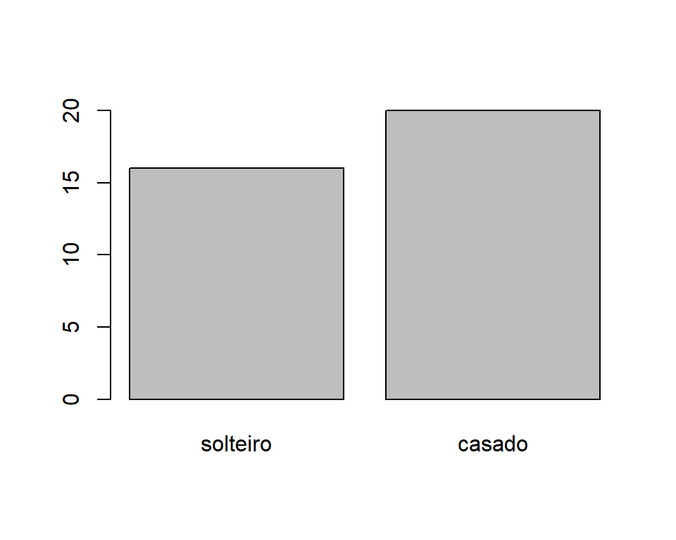

```r
# Grafico de barras e pizza - construa uma tabela de frequencias primeiro!
barplot(t1)
```

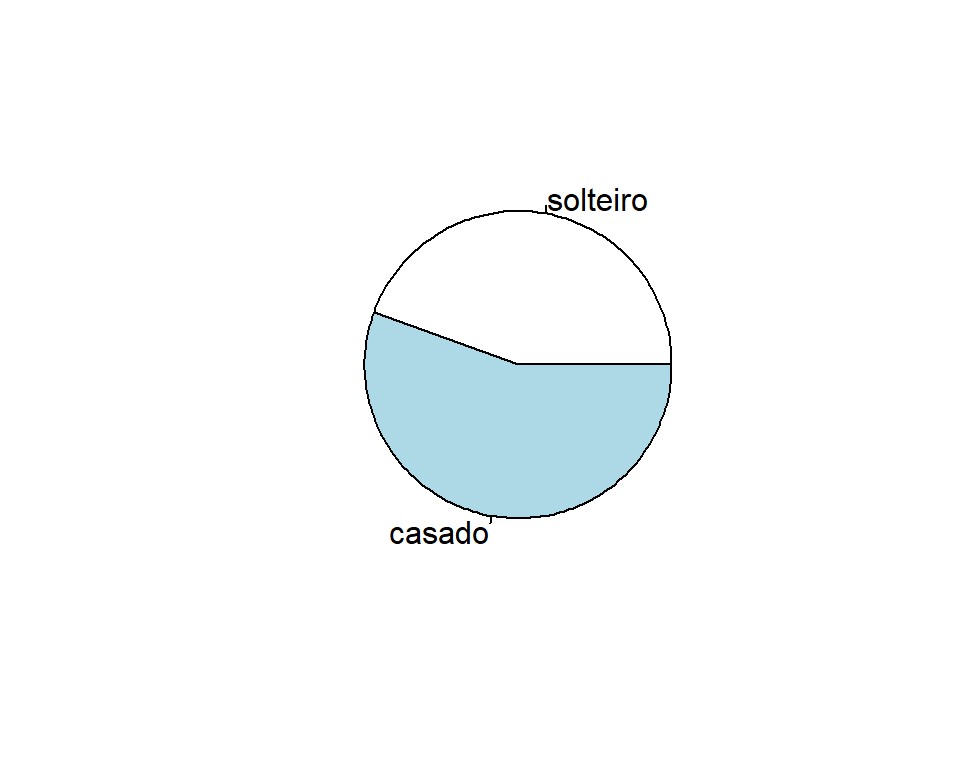

```r
pie(t1)
```

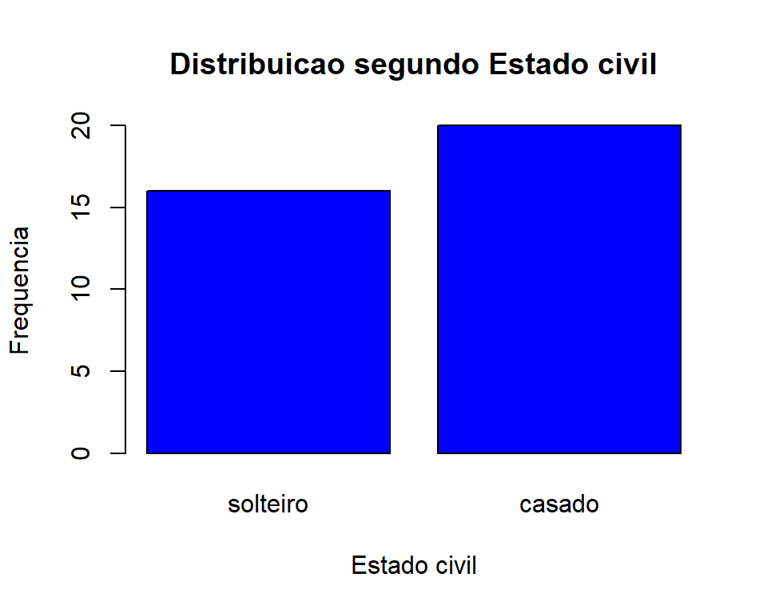

```r
# Tem como melhorar este grafico?

barplot(t1, main = "Distribuicao segundo Estado civil", ylab = "Frequencia", xlab = "Estado civil", col = "blue")
```

[figure not shown]

```r
pie(t1, labels = paste(c("casado - ", "solteiro - "), round(prop.table(t1)*100, 2), "%", sep = ""),
    main = "Distribuicao segundo estado civil", col = c("blue", "red"))
```

```r
# x11() Ou win.graph() podem ser usados para abrir uma nova janela gráfica
```

### Note que a função plot retorna diferentes resultados dependendo do tipo do objeto.

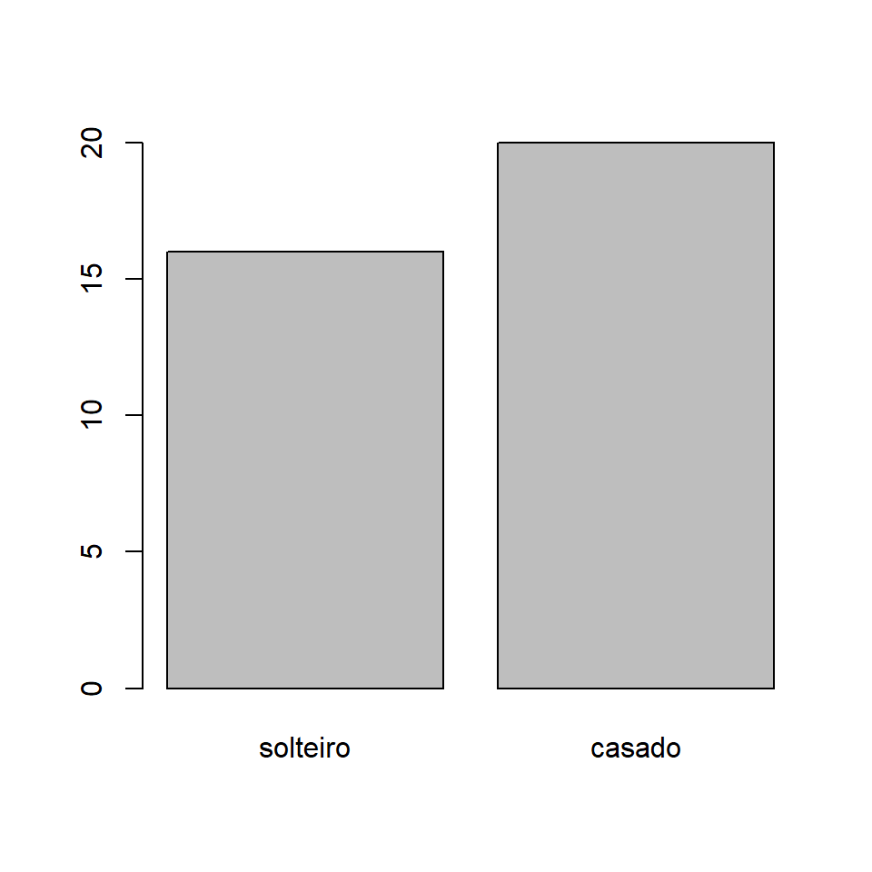

```r
attach(milsa)
plot(civil)
```

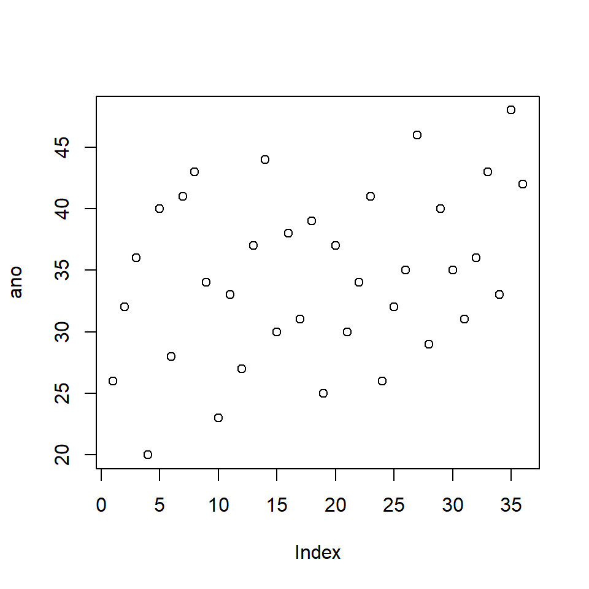

```r
plot(ano)
```

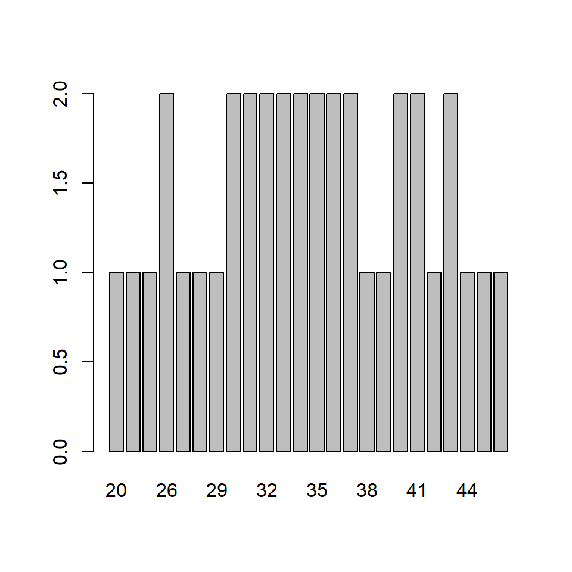

```r
plot(factor(ano))
```

### Podemos plotar dos dois gráficos na mesma janela gráfica?

[figure not shown]

```r
par(mfrow = c(1,2), oma = (4:1))

barplot(t1, main = "Estado civil", ylab = "Frequencia", xlab = "Estado civil",col = "red", col.axis = "blue")

pie(t1, labels = paste(c("casado - ", "solteiro - "), round(prop.table(t1)*100, 2), "%", sep = ""),
    main = "Estado civil", col = c("blue", "red"))
```

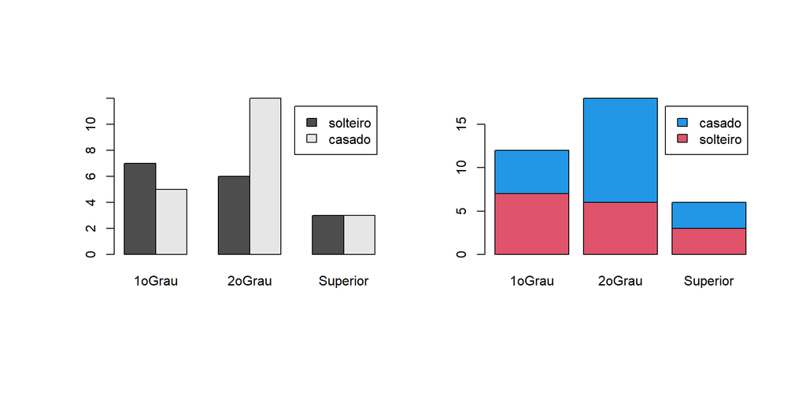

```r
# Graficos de barras para duas variaveis
barplot(t2, beside = T, legend = T)
barplot(t2, beside = F, legend = T, col = c(2, 4))
```

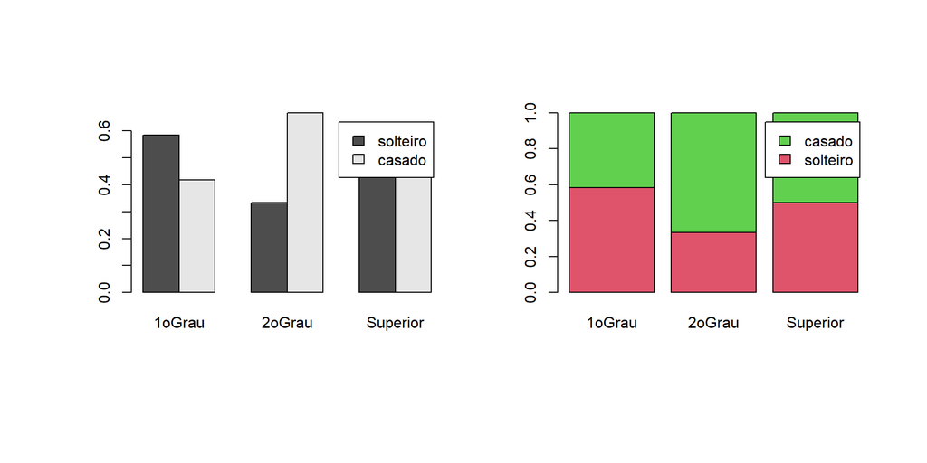

```r
# Usando proporções
barplot(prop.table(t2, 2), beside = T, legend = T)
barplot(prop.table(t2, 2), beside = F, legend = T, col = c(2, 3))
```

### Principais parâmetros gráficos do R

Função `par` define vários parâmetros da janela gráfica atual. Por exemplo, `par(mfrow=c(1,2))` permite colocar dois gráficos lado a lado.

- Cada tipo de gráfico permite configurar inúmeros parâmetros. Alguns deles são:
  - main: Título do gráfico;
  - sub: Subtítulo do gráfico;
  - xlab e ylab: nomes dos eixos;
  - col: relacionado a cor do gráfico;
  - cex.axis, cex.lab, cex.main, cex.sub: relativo ao tamanho da letra;
  - cex: relacionado a tamanho de pontos;
  - xlim e ylim: referente a escala que aparece nos eixos $x$ e $y$;

Consulte o help da função `par` para saber quais parâmetros gráficos podem ser alterados.

Quais cores podemos utilizar?

```r
# Quais cores podemos usar
colours()
```

```
##   [1] "white"                "aliceblue"            "antiquewhite"
##   [4] "antiquewhite1"        "antiquewhite2"        "antiquewhite3"
##   [7] "antiquewhite4"        "aquamarine"           "aquamarine1"
##  [10] "aquamarine2"          "aquamarine3"          "aquamarine4"
##  [13] "azure"                "azure1"               "azure2"
##  [16] "azure3"               "azure4"               "beige"
##  [19] "bisque"               "bisque1"              "bisque2"
##  [22] "bisque3"              "bisque4"              "black"
##  [25] "blanchedalmond"       "blue"                 "blue1"
##  [28] "blue2"                "blue3"                "blue4"
##  [31] "blueviolet"           "brown"                "brown1"
##  [34] "brown2"               "brown3"               "brown4"
##  [37] "burlywood"            "burlywood1"           "burlywood2"
##  [40] "burlywood3"           "burlywood4"           "cadetblue"
##  [43] "cadetblue1"           "cadetblue2"           "cadetblue3"
```

[output cut: 204 more lines]

[figure not shown]

[figure not shown]

## Análise descritiva e exploratória de dados - variáveis quantitativas

```
Algumas funções usadas para a calcular medidas resumo de variáveis quantitativas são:
```

- mean, median, summary, quantile;
- sum, max, min;
- var, sd;

```r
data(iris)   # entre parenteses informamos o nome do conjunto de dados
iris          # exibe o conjunto de dados
```

```
##     Sepal.Length Sepal.Width Petal.Length Petal.Width    Species
## 1            5.1         3.5          1.4         0.2     setosa
## 2            4.9         3.0          1.4         0.2     setosa
## 3            4.7         3.2          1.3         0.2     setosa
## 4            4.6         3.1          1.5         0.2     setosa
## 5            5.0         3.6          1.4         0.2     setosa
## 6            5.4         3.9          1.7         0.4     setosa
## 7            4.6         3.4          1.4         0.3     setosa
## 8            5.0         3.4          1.5         0.2     setosa
## 9            4.4         2.9          1.4         0.2     setosa
## 10           4.9         3.1          1.5         0.1     setosa
## 11           5.4         3.7          1.5         0.2     setosa
## 12           4.8         3.4          1.6         0.2     setosa
## 13           4.8         3.0          1.4         0.1     setosa
## 14           4.3         3.0          1.1         0.1     setosa
```

[output cut: 136 more lines]

```r
head(iris)
```

```
##   Sepal.Length Sepal.Width Petal.Length Petal.Width Species
## 1          5.1         3.5          1.4         0.2  setosa
## 2          4.9         3.0          1.4         0.2  setosa
## 3          4.7         3.2          1.3         0.2  setosa
## 4          4.6         3.1          1.5         0.2  setosa
## 5          5.0         3.6          1.4         0.2  setosa
## 6          5.4         3.9          1.7         0.4  setosa
```

```r
attach(iris)


## Medidas resumo
# Medidas de posicao - mean, median, min, max, quantile

summary(Sepal.Length) # Para uma variavel apenas
```

```
##    Min. 1st Qu.  Median    Mean 3rd Qu.    Max.
##   4.300   5.100   5.800   5.843   6.400   7.900
```

```r
summary(iris) # para todas as variaveis
```

```
##   Sepal.Length    Sepal.Width     Petal.Length    Petal.Width
##  Min.   :4.300   Min.   :2.000   Min.   :1.000   Min.   :0.100
##  1st Qu.:5.100   1st Qu.:2.800   1st Qu.:1.600   1st Qu.:0.300
##  Median :5.800   Median :3.000   Median :4.350   Median :1.300
##  Mean   :5.843   Mean   :3.057   Mean   :3.758   Mean   :1.199
##  3rd Qu.:6.400   3rd Qu.:3.300   3rd Qu.:5.100   3rd Qu.:1.800
##  Max.   :7.900   Max.   :4.400   Max.   :6.900   Max.   :2.500
##        Species
##  setosa    :50
##  versicolor:50
##  virginica :50
##
##
##
```

```r
# Podemos extratificar pela variavel categorica - 3 alternativas
summary(Sepal.Length[Species=="setosa"])
```

```
##    Min. 1st Qu.  Median    Mean 3rd Qu.    Max.
##   4.300   4.800   5.000   5.006   5.200   5.800
```

```r
summary(Sepal.Length[Species=="versicolor"])
```

```
##    Min. 1st Qu.  Median    Mean 3rd Qu.    Max.
##   4.900   5.600   5.900   5.936   6.300   7.000
```

```r
summary(Sepal.Length[Species=="virginica"])
```

```
##    Min. 1st Qu.  Median    Mean 3rd Qu.    Max.
##   4.900   6.225   6.500   6.588   6.900   7.900
```

```r
by(iris[,-5], Species, summary)
```

```
## Species: setosa
##   Sepal.Length    Sepal.Width     Petal.Length    Petal.Width
##  Min.   :4.300   Min.   :2.300   Min.   :1.000   Min.   :0.100
##  1st Qu.:4.800   1st Qu.:3.200   1st Qu.:1.400   1st Qu.:0.200
##  Median :5.000   Median :3.400   Median :1.500   Median :0.200
##  Mean   :5.006   Mean   :3.428   Mean   :1.462   Mean   :0.246
##  3rd Qu.:5.200   3rd Qu.:3.675   3rd Qu.:1.575   3rd Qu.:0.300
##  Max.   :5.800   Max.   :4.400   Max.   :1.900   Max.   :0.600
## ------------------------------------------------------------
## Species: versicolor
##   Sepal.Length    Sepal.Width     Petal.Length   Petal.Width
##  Min.   :4.900   Min.   :2.000   Min.   :3.00   Min.   :1.000
##  1st Qu.:5.600   1st Qu.:2.525   1st Qu.:4.00   1st Qu.:1.200
##  Median :5.900   Median :2.800   Median :4.35   Median :1.300
##  Mean   :5.936   Mean   :2.770   Mean   :4.26   Mean   :1.326
##  3rd Qu.:6.300   3rd Qu.:3.000   3rd Qu.:4.60   3rd Qu.:1.500
##  Max.   :7.000   Max.   :3.400   Max.   :5.10   Max.   :1.800
## ------------------------------------------------------------
## Species: virginica
##   Sepal.Length    Sepal.Width     Petal.Length    Petal.Width
##  Min.   :4.900   Min.   :2.200   Min.   :4.500   Min.   :1.400
##  1st Qu.:6.225   1st Qu.:2.800   1st Qu.:5.100   1st Qu.:1.800
##  Median :6.500   Median :3.000   Median :5.550   Median :2.000
##  Mean   :6.588   Mean   :2.974   Mean   :5.552   Mean   :2.026
##  3rd Qu.:6.900   3rd Qu.:3.175   3rd Qu.:5.875   3rd Qu.:2.300
##  Max.   :7.900   Max.   :3.800   Max.   :6.900   Max.   :2.500
```

```r
tapply(Sepal.Length, Species, summary)
```

```
## $setosa
##    Min. 1st Qu.  Median    Mean 3rd Qu.    Max.
##   4.300   4.800   5.000   5.006   5.200   5.800
##
## $versicolor
##    Min. 1st Qu.  Median    Mean 3rd Qu.    Max.
##   4.900   5.600   5.900   5.936   6.300   7.000
##
## $virginica
##    Min. 1st Qu.  Median    Mean 3rd Qu.    Max.
##   4.900   6.225   6.500   6.588   6.900   7.900
```

```r
# Medidas de variabilidade -
var(Sepal.Length)  # variancia
```

```
## [1] 0.6856935
```

```r
sd(Sepal.Length)   # desvio padrao
```

```
## [1] 0.8280661
```

```r
var(iris[, 1:4]) ## matrix de covariancias
```

```
##              Sepal.Length Sepal.Width Petal.Length Petal.Width
## Sepal.Length    0.6856935  -0.0424340    1.2743154   0.5162707
## Sepal.Width    -0.0424340   0.1899794   -0.3296564  -0.1216394
## Petal.Length    1.2743154  -0.3296564    3.1162779   1.2956094
## Petal.Width     0.5162707  -0.1216394    1.2956094   0.5810063
```

```r
# sd(iris[,1:4]) ## Nao aceita data.frame

cv <- sd(Sepal.Length)/mean(Sepal.Length) # coeficiente de variacao

tapply(Sepal.Length, Species, sd)
```

```
##     setosa versicolor  virginica
##  0.3524897  0.5161711  0.6358796
```

```r
# Quantis
quantile(Sepal.Length, probs = c(0.10, 0.25, 0.50, 0.75, 0.90))
```

```
## 10% 25% 50% 75% 90%
## 4.8 5.1 5.8 6.4 6.9
```

### Alguns tipos de gráficos

- Gráfico de dispersão;
- Histograma;
- Boxplot;
- Gráfico de ramo e folhas;
- Diagrama de pontos

#### Gráfico de dispersão

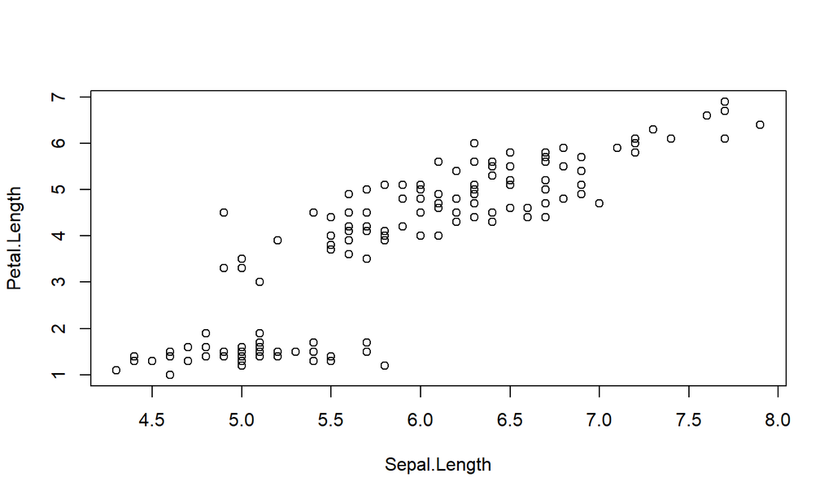

```r
# Grafico
plot(Sepal.Length, Petal.Length)
```

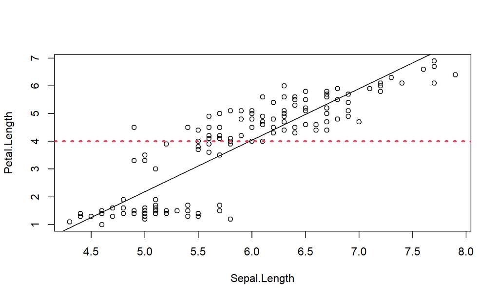

```r
plot(Petal.Length ~ Sepal.Length)
abline(lm(Petal.Length ~ Sepal.Length)) ## Se houver comportamento linear
abline(h = 4, lwd = 3, lty = 3, col = 2)
```

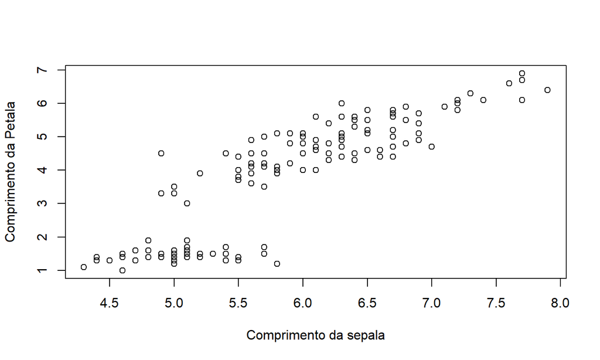

```r
plot(Sepal.Length, Petal.Length, xlab = "Comprimento da sepala",
     ylab = "Comprimento da Petala")
```

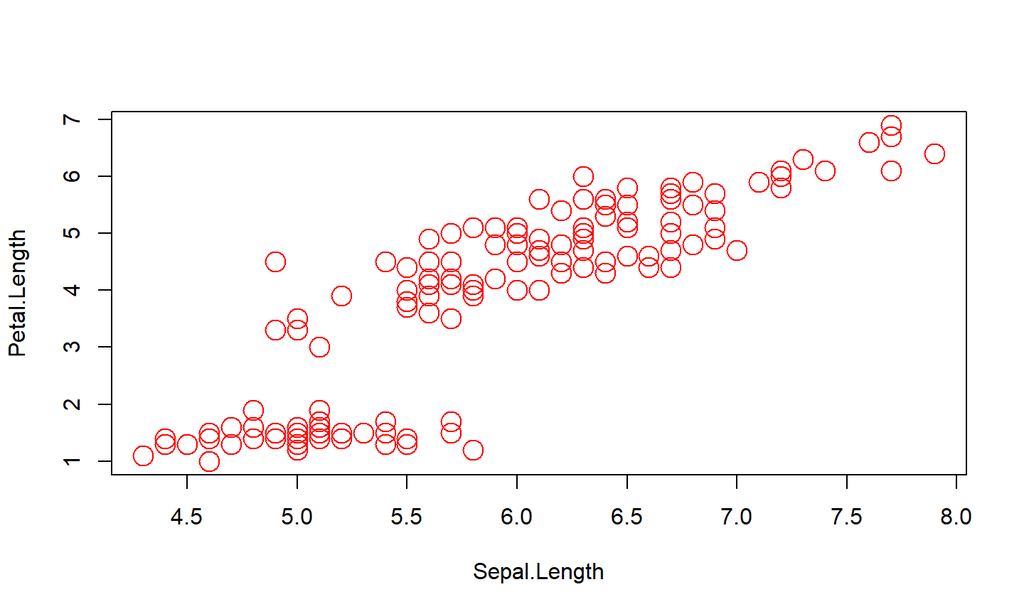

```r
## podemos, por exemplo, mudar o tamanho dos pontos ou a cor
plot(Sepal.Length, Petal.Length, cex = 2, col = "red")
```

```r
## coeficiente de correlacao de pearson
cor(Sepal.Length, Petal.Length)
```

```
## [1] 0.8717538
```

#### Separando por Especie

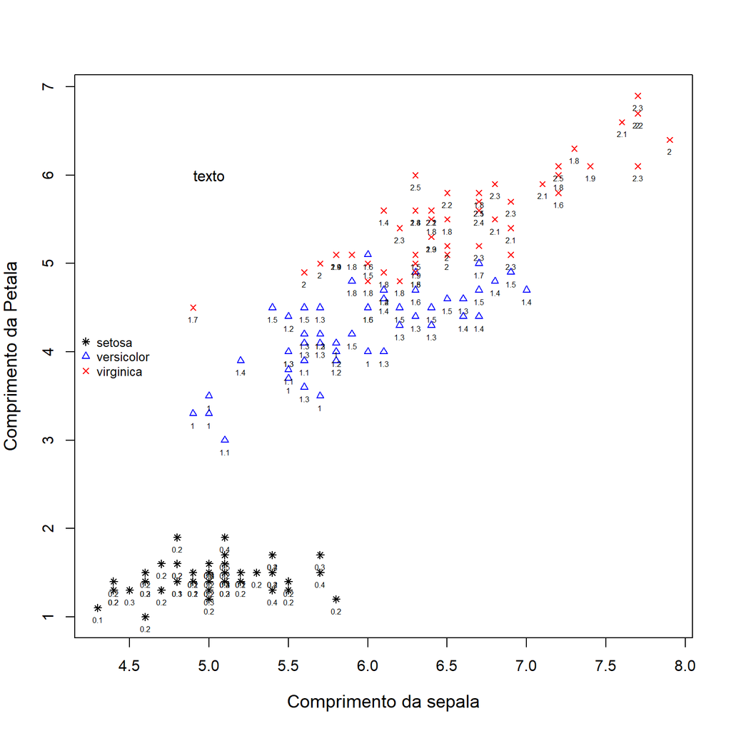

```r
plot(Sepal.Length[Species == "setosa"], Petal.Length[Species == "setosa"],
     cex = 0.8, pch = 8, xlim = range(Sepal.Length), ylim = range(Petal.Length),
     xlab = "Comprimento da sepala", ylab = "Comprimento da Petala", cex.lab = 1.2)

points(Sepal.Length[Species == "versicolor"], Petal.Length[Species == "versicolor"],
       cex = 0.8, pch = 2, col = "blue")

points(Sepal.Length[Species == "virginica"], Petal.Length[Species == "virginica"],
       cex = 0.8, pch = 4, col = "red")

# Incluindo uma lengenda
legend("left", c("setosa", "versicolor", "virginica"), pch = c(8, 2, 4),
       col = c("black", "blue", "red"), cex = 0.8, bty = "n")

# Se quisermos algum texto dentro do grafico
text(Sepal.Length, Petal.Length, labels = round(Petal.Width, 2), pos = 1, offset = 0.5, cex = 0.5)

text(5, 6, "texto")
```

#### Mais sobre a função plot

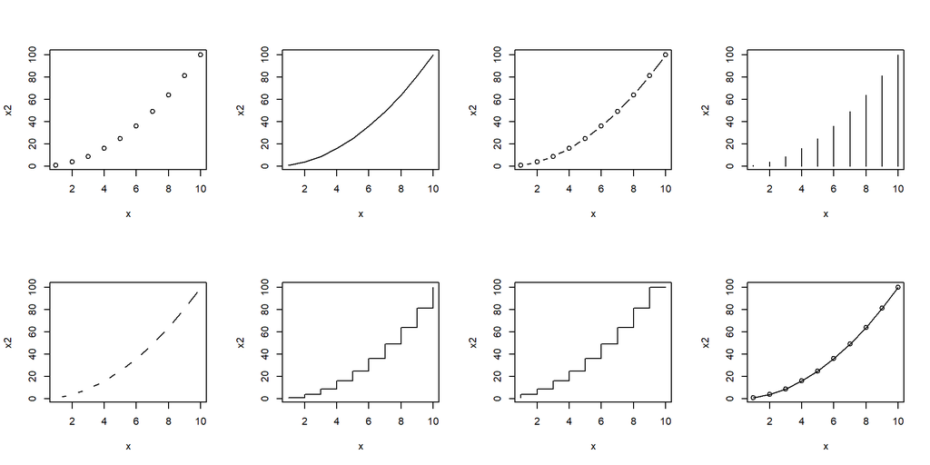

```r
##
x = seq(1, 10, by = )
x2 = x^2
par(mfrow = c(2, 4))
plot(x, x2)
plot(x, x2, type = "l")
plot(x, x2, type = "b")
plot(x, x2, type = "h")
plot(x, x2, type = "c")
plot(x, x2, type = "s")
plot(x, x2, type = "S")
plot(x, x2, type = "o")
```

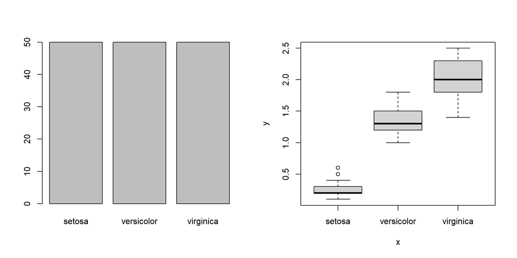

```r
## O que acontece se plotamos uma variável categórica?
## E uma variável categórica versus uma variavel continua?
par(mfrow = c(1, 2))
plot(Species)
plot(Species, Petal.Width)
```

#### Mais Gráficos

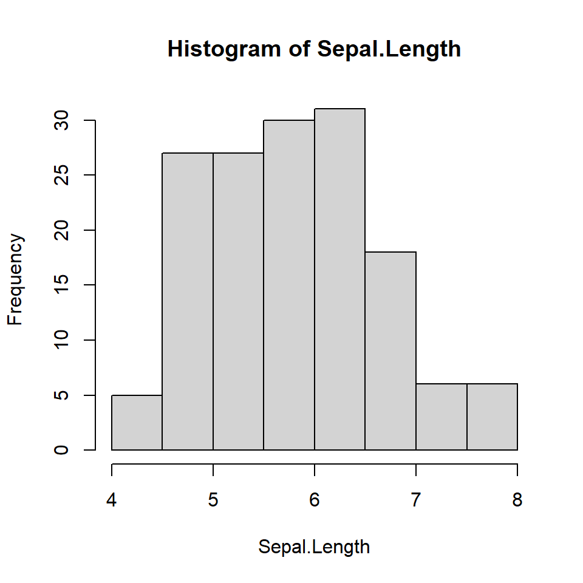

```r
# Histograma
hist(Sepal.Length)
```

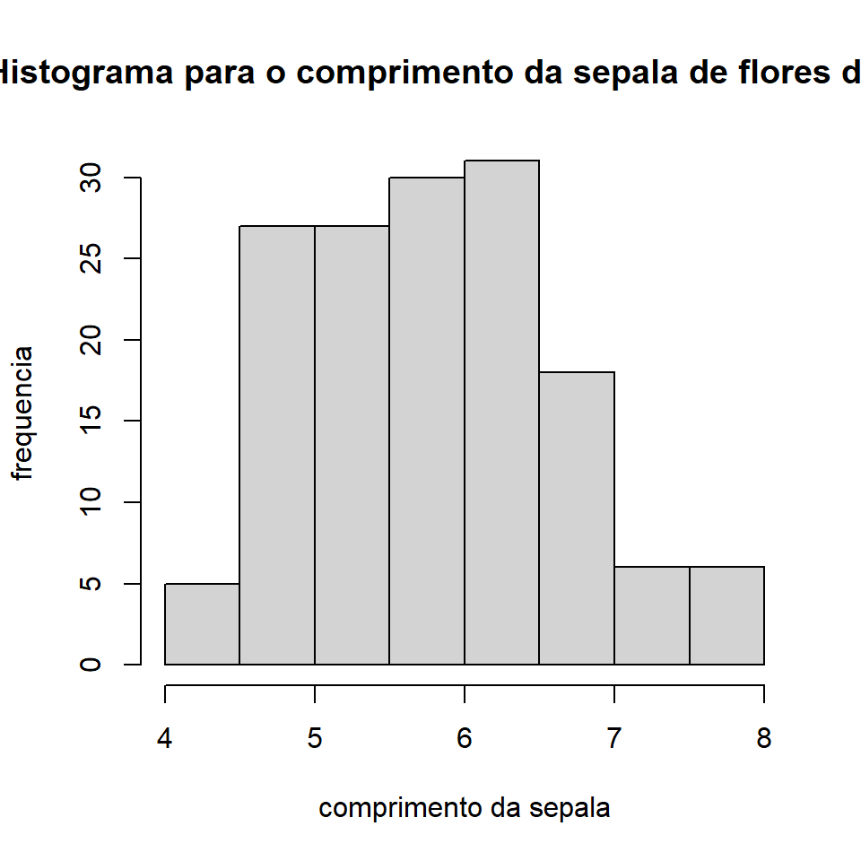

```r
hist(Sepal.Length, main = "Histograma para o comprimento da sepala de flores de iris",
     xlab = "comprimento da sepala", ylab = "frequencia")
```

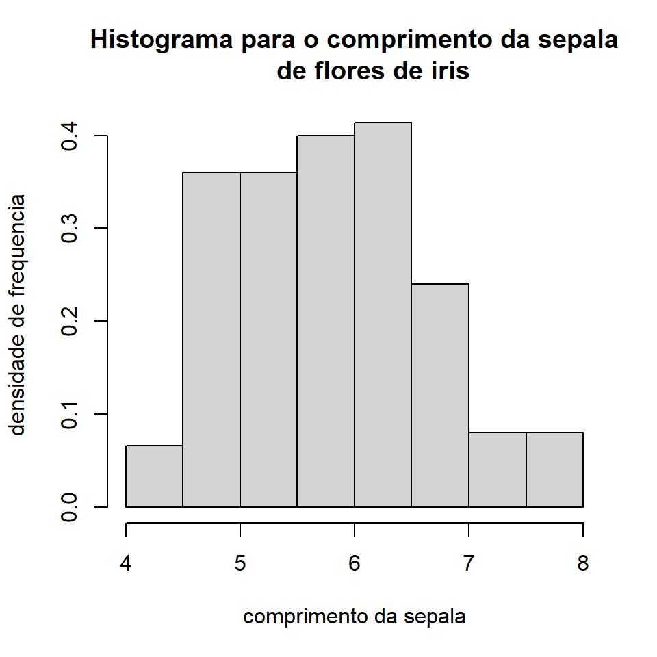

```r
hist(Sepal.Length, freq = F, main =" Histograma para o comprimento da sepala
     de flores de iris", xlab = "comprimento da sepala", ylab = "densidade de frequencia")
```

```r
# Diagrama de ramo e folhas
stem(Sepal.Length)
```

```
##
##   The decimal point is 1 digit(s) to the left of the |
##
##   42 | 0
##   44 | 0000
##   46 | 000000
##   48 | 00000000000
##   50 | 0000000000000000000
##   52 | 00000
##   54 | 0000000000000
##   56 | 00000000000000
##   58 | 0000000000
##   60 | 000000000000
##   62 | 0000000000000
##   64 | 000000000000
##   66 | 0000000000
##   68 | 0000000
##   70 | 00
##   72 | 0000
##   74 | 0
##   76 | 00000
##   78 | 0
```

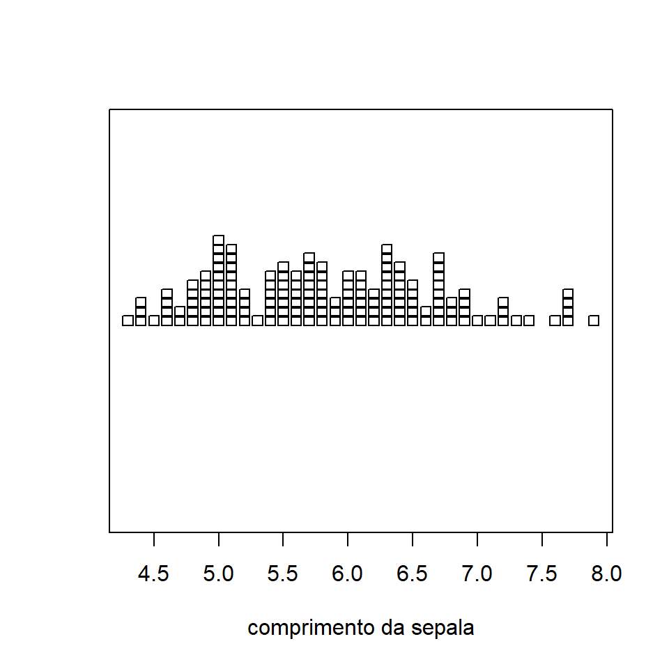

```r
# Diagrama de pontos
stripchart(Sepal.Length, method = "stack", xlab = "comprimento da sepala")
```

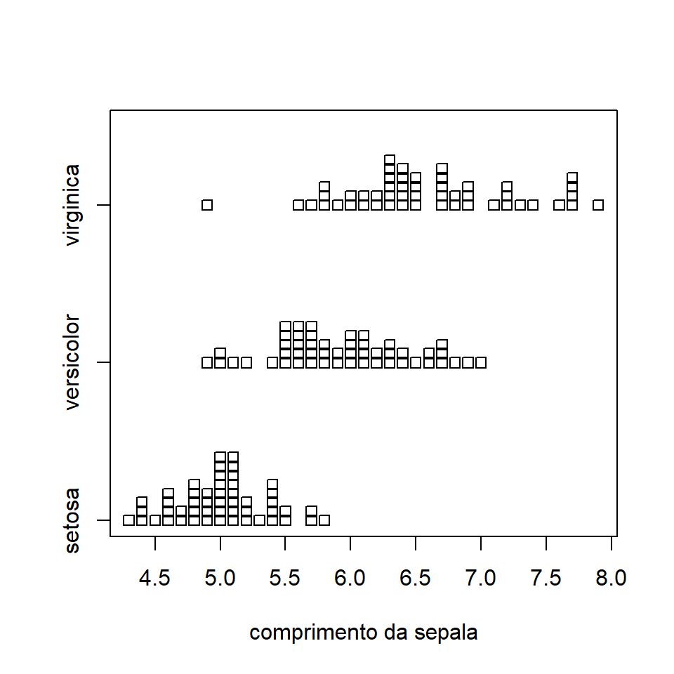

```r
stripchart(Sepal.Length ~ Species, method = "stack", xlab = "comprimento da sepala")
```

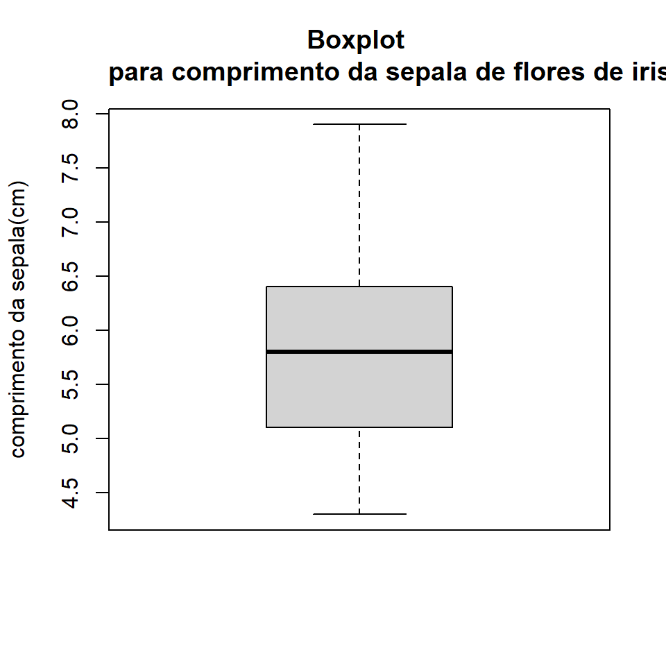

```r
# Boxplot
boxplot(Sepal.Length, ylab = "comprimento da sepala(cm)", main = "Boxplot
        para comprimento da sepala de flores de iris")
```

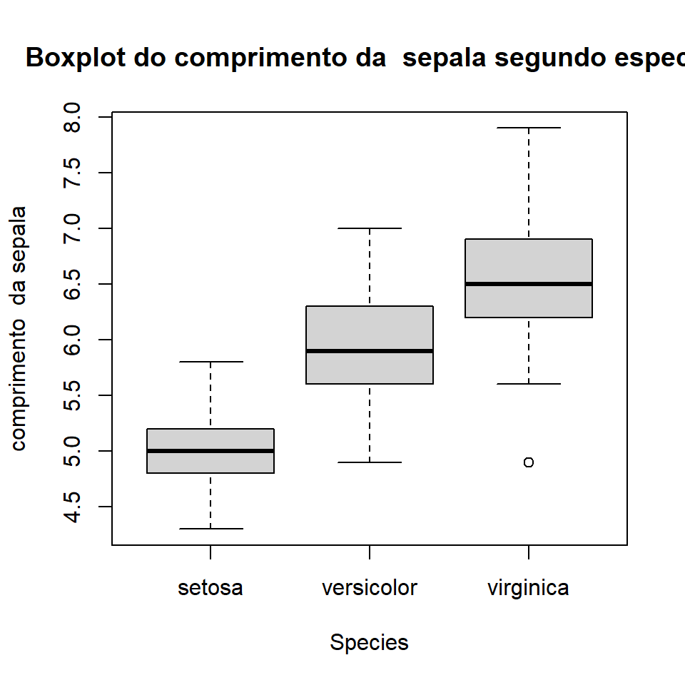

```r
boxplot(Sepal.Length ~ Species, ylab = "comprimento  da sepala", main =
          "Boxplot do comprimento da  sepala segundo especie")
```

```r
## Correlograma
M <- cor(mtcars)
head(round(M, 2))
```

```
##        mpg   cyl  disp    hp  drat    wt  qsec    vs    am  gear  carb
## mpg   1.00 -0.85 -0.85 -0.78  0.68 -0.87  0.42  0.66  0.60  0.48 -0.55
## cyl  -0.85  1.00  0.90  0.83 -0.70  0.78 -0.59 -0.81 -0.52 -0.49  0.53
## disp -0.85  0.90  1.00  0.79 -0.71  0.89 -0.43 -0.71 -0.59 -0.56  0.39
## hp   -0.78  0.83  0.79  1.00 -0.45  0.66 -0.71 -0.72 -0.24 -0.13  0.75
## drat  0.68 -0.70 -0.71 -0.45  1.00 -0.71  0.09  0.44  0.71  0.70 -0.09
## wt   -0.87  0.78  0.89  0.66 -0.71  1.00 -0.17 -0.55 -0.69 -0.58  0.43
```

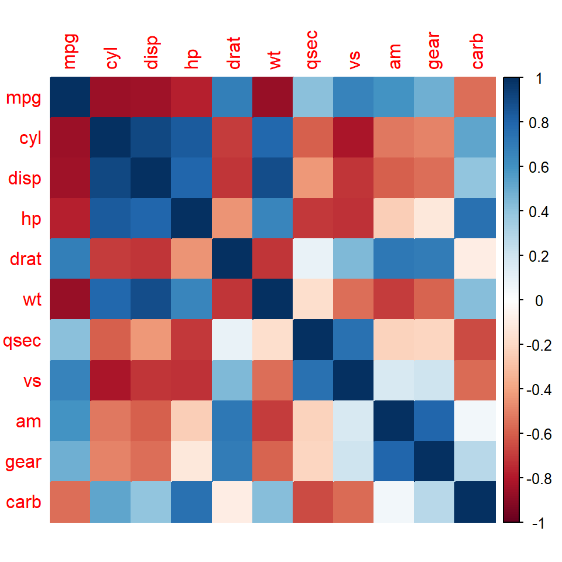

```r
library(corrplot)
corrplot(M, method = "color")
```

#### Para histogramas separados por espécie

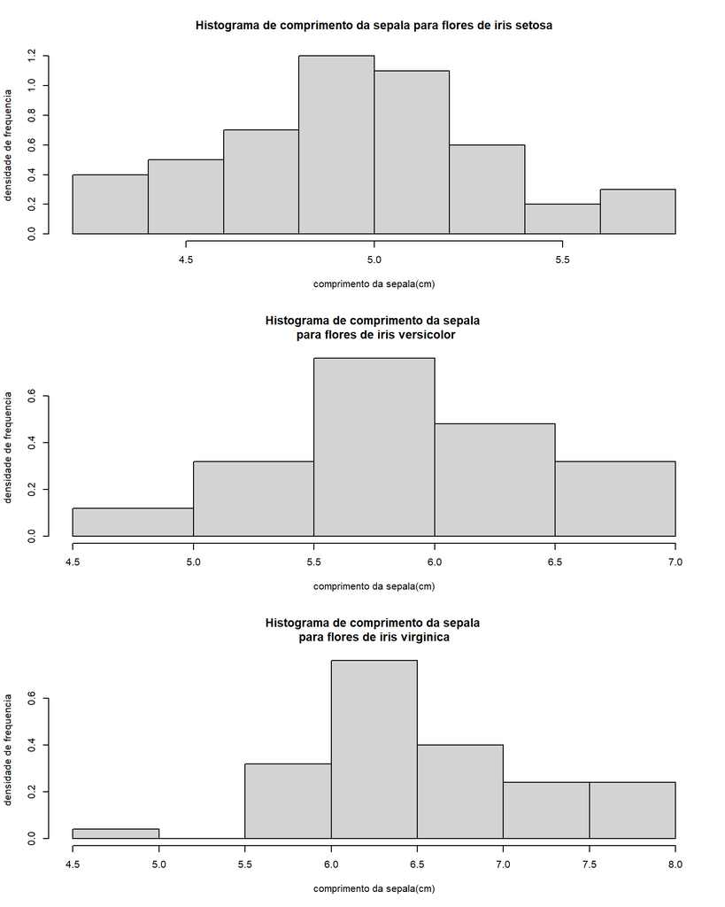

```r
par(mfrow=c(3,1))
hist(Sepal.Length[Species=="setosa"],freq=F,main="Histograma de comprimento da sepala para flores de iris setosa",
     xlab="comprimento da sepala(cm)",ylab="densidade de frequencia")

hist(Sepal.Length[Species=="versicolor"],freq=F,main="Histograma de comprimento da sepala \n para flores de iris versicolor",
     xlab="comprimento da sepala(cm)",ylab="densidade de frequencia")

hist(Sepal.Length[Species=="virginica"],freq=F,main="Histograma de comprimento da sepala
para flores de iris virginica", xlab="comprimento da sepala(cm)", ylab="densidade de frequencia")
```

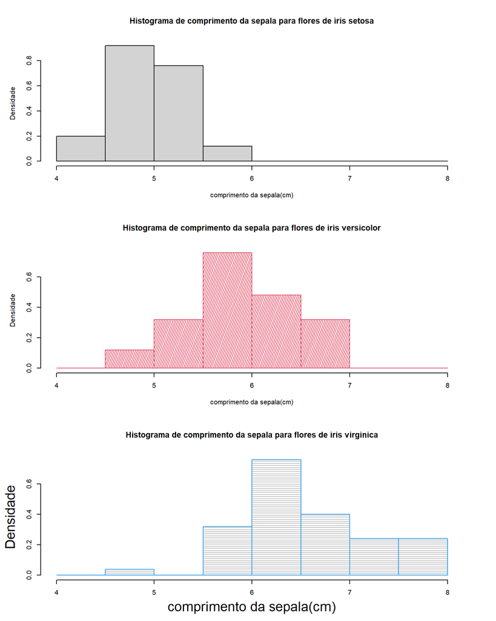

```r
#--------------------------------------------------------
# Para facilitar a comparacao podemos especificar as mesmas classes para os 3 histogramas como o
# argumento breaks (limites de classe).


par(mfrow=c(3,1), mar= c(5,5,5,4)) ## alterando as margens da janela grafica
hist(Sepal.Length[Species=="setosa"],freq=F,breaks=seq(4,8,0.5),main = "Histograma de comprimento da sepala para flores de iris setosa",
     xlab="comprimento da sepala(cm)",ylab="Densidade")

hist(Sepal.Length[Species=="versicolor"],freq=F,breaks=seq(4,8,0.5),
     main="Histograma de comprimento da sepala para flores de iris versicolor",
     xlab="comprimento da sepala(cm)", ylab="Densidade",  col=2, angle = 70, density = 40)

hist(Sepal.Length[Species=="virginica"],freq=F, breaks=seq(4,8,0.5),
     main="Histograma de comprimento da sepala para flores de iris virginica",
     xlab="comprimento da sepala(cm)", ylab = "Densidade",
     border = 4, col = "gray", density = 30, angle=180, cex.lab=2)
```

```r
## Repare que diversos argumentos podem ser alterados para darem outra cara aos graficos
```

## Mais sobre plot, lines, etc

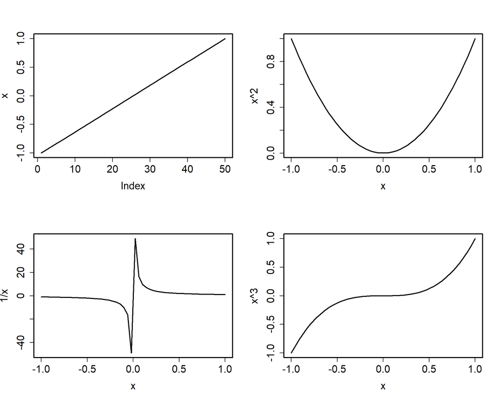

```r
n <- 50
x <- seq(-1,1,length=n)
op <- par(mfrow=c(2,2), lwd=2, cex.axis=1.5, cex.lab=1.5)
plot(x, type="l")
plot(x, x^2, type="l")
plot(x, 1/x, type="l")
plot(x, x^3, type="l")
```

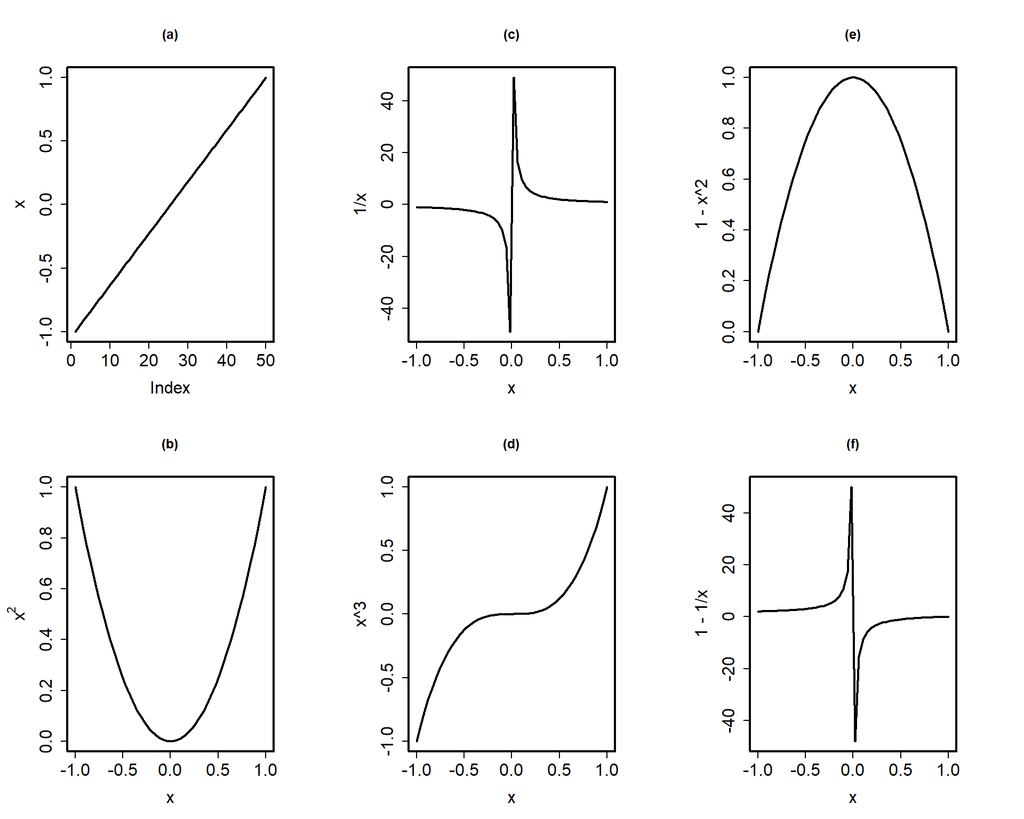

```r
# um outro exemplo
op <- par(mfcol=c(2,3), lwd=2, cex.axis=1.5, cex.lab=1.5, mar=c(5,5,5,5))
plot(x, type="l", main="(a)")
plot(x, x^2, type="l", main="(b)",ylab=expression(x^2))
plot(x, 1/x, type="l", main="(c)")
plot(x, x^3, type="l", main="(d)")
plot(x,1-x^2, type="l", main="(e)")
plot(x, 1-1/x, type="l", main="(f)")
```

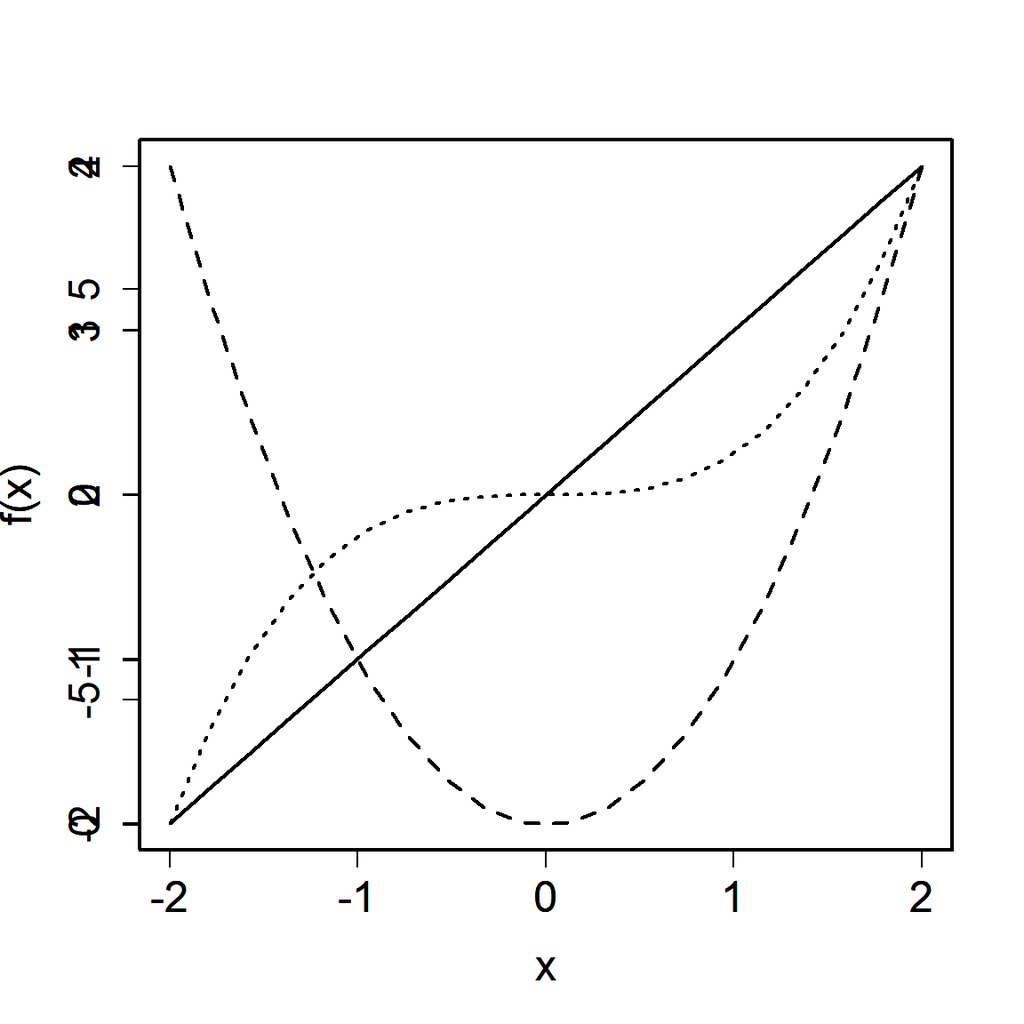

```r
## Ilustrando o par(new=TRUE)
op <- par(mfrow=c(1,1), lwd=2, cex.axis=1.5, cex.lab=1.5)
n <- 20
x <- seq(-2,2,length=n)
y1 <- x
y2 <- x^2
y3 <- x^3
plot(x,y1, xlab="x", ylab="f(x)", type="l", lwd=2)
par(new=TRUE)
plot(x,y2, xlab="x", ylab="f(x)", type="l", lwd=2, lty=2)
par(new=TRUE)
plot(x,y3, xlab="x", ylab="f(x)", type="l", lwd=2, lty=3)
```

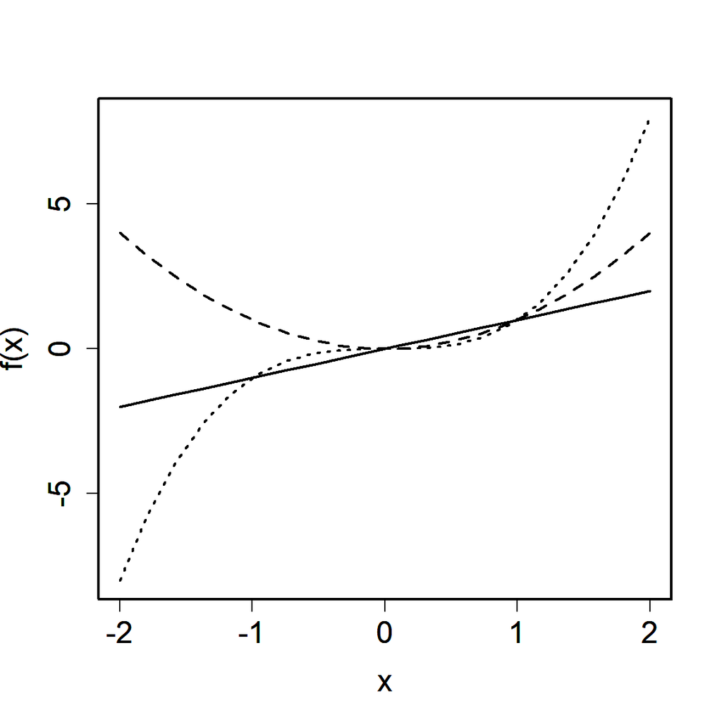

```r
# acertando os eixos:

plot(x,y1, xlab="x", ylab="f(x)", type="l", lwd=2, xlim=range(x),
     ylim=range(y1,y2,y3))
par(new=TRUE)
plot(x,y2, xlab="x", ylab="f(x)", type="l", lwd=2, lty=2,
     ylim=range(y1,y2,y3))
par(new=TRUE)
plot(x,y3, xlab="x", ylab="f(x)", type="l", lwd=2, lty=3,
     ylim=range(y1,y2,y3))
```

### line e abline

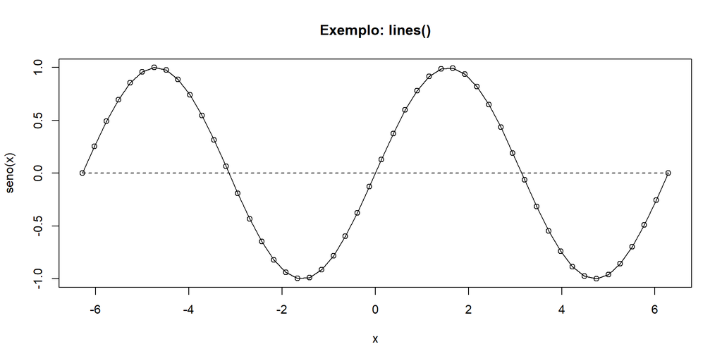

```r
n <- 50
x <- seq(-2*pi,2*pi, length=n)
y <- sin(x)

# aplicando a funcoes lines
plot(x,y, xlab="x", ylab="seno(x)", main="Exemplo: lines()")
lines(x,y)
lines(x, rep(0,n), lty=2)
```

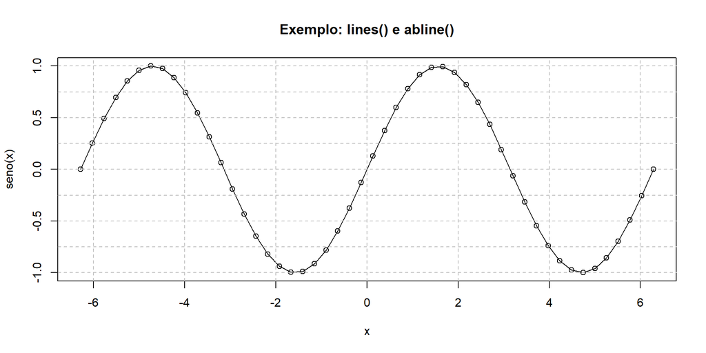

```r
# aplicando simultaneamente as funcoes lines e abline:

plot(x,y, xlab="x", ylab="seno(x)", main="Exemplo: lines() e abline()")
lines(x,y)
x.axis <- seq(-6,6,by=2)
y.axis <- seq(-1,1,by=0.25)
abline(v=x.axis, h=y.axis, lty=2, col="gray")
```

### Legendas com expressões matemáticas:

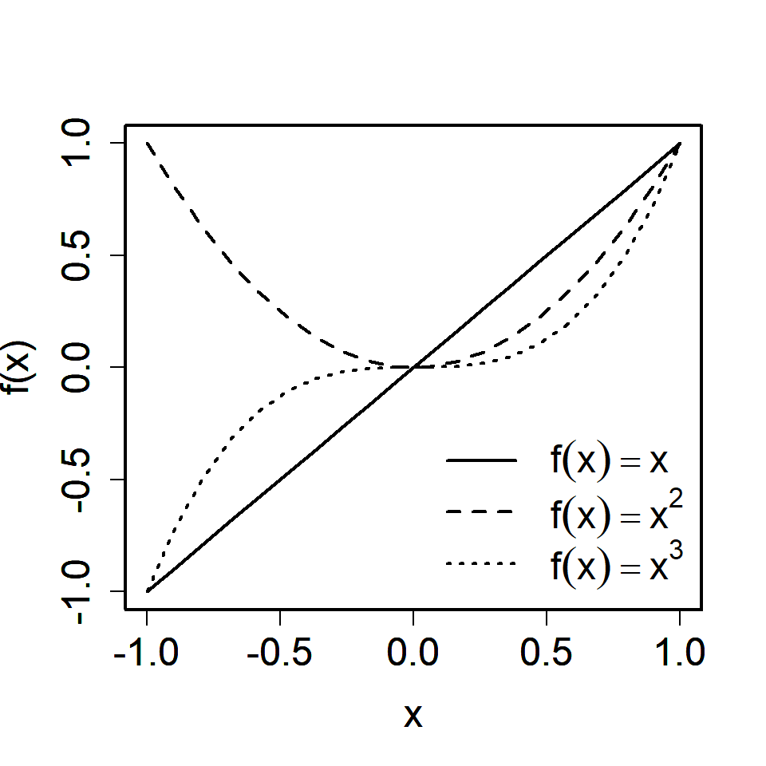

```r
# legendas com expressoes matematicas:
n <- 20
x <- seq(-1,1,length=n)
y1 <- x
y2 <- x^2
y3 <- x^3
op <- par(lwd=2, cex.axis=1.5, cex.lab=1.5)
plot(x,y1, xlim=range(x), ylim=range(y1,y2,y3), xlab="x", ylab="f(x)", type="l")
par(new=TRUE)
plot(x,y2, xlim=range(x), ylim=range(y1,y2,y3), xlab="x", ylab="f(x)", type="l",
     lty=2)
par(new=TRUE)
plot(x,y3, xlim=range(x), ylim=range(y1,y2,y3), xlab="x", ylab="f(x)", type="l",
     lty=3)
legend("bottomright", lty=1:3, c(expression(f(x)==x), expression(f(x)==x^2),
                                 expression(f(x)==x^3)), lwd=2, bty="n", cex=1.5)
```

### Ilustrando o uso das funções segments e arrows:

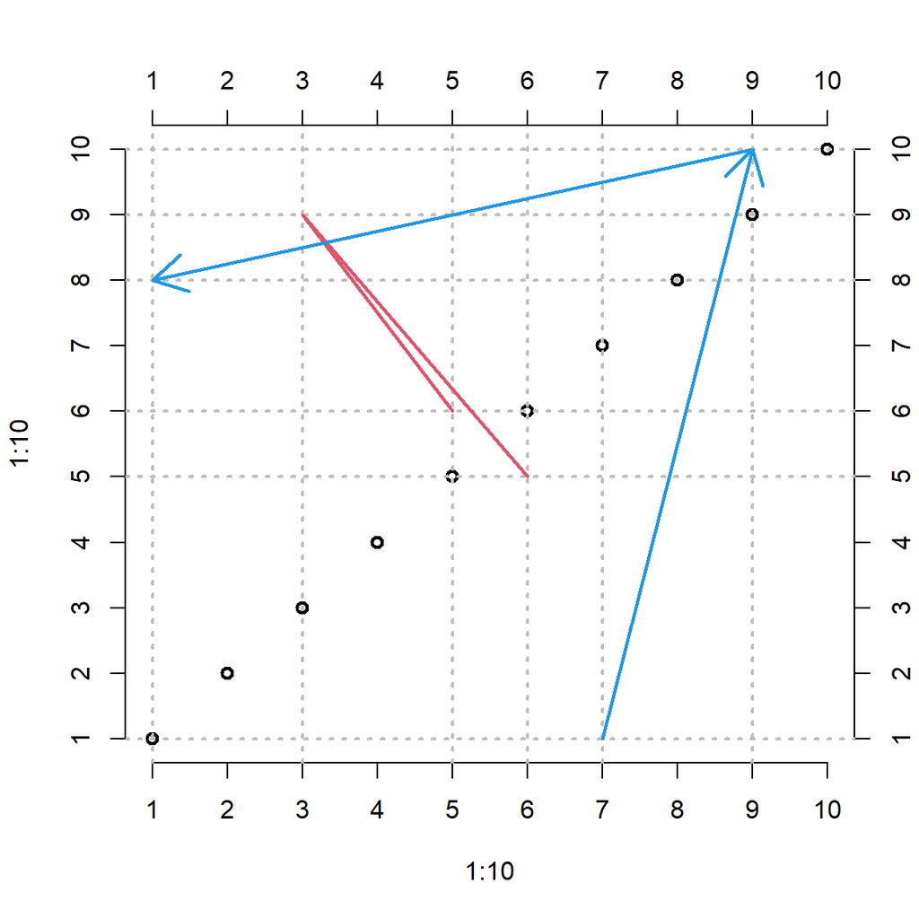

```r
 x = sample(1:10, 6)
 y = sample(1:10, 6)

 par(lwd=2)
 plot(1:10, 1:10, axes=FALSE)
 axis(1,1:10)
 axis(2,1:10)
 axis(3,1:10)
 axis(4,1:10)
 abline(h=y, v=x, col="gray", lty=3)
 segments(x[1], y[1], x[2], y[2], col = 2)
 segments(x[2], y[2], x[3], y[3], col = 2)
 arrows(x[4], y[4], x[5], y[5], col = 4)
 arrows(x[5], y[5], x[6], y[6], col = 4)
```

## Pacotes para obtenção de tabelas com estatísticas descritivas

Existem vários pacotes para a obtenção de estatísticas descritivas.

- Alguns deles são: summarytools, descriptr, Summarytools, SmartEDA, TescTools, skimr, gtsummary, gmodels, Hmisc, pastecs.
- https://dabblingwithdata.amedcalf.com/2018/01/02/my-favourite-r-package-for-summarising-data/

### jmv - Jamovi

```r
library("jmv")
data('mtcars')
dat <- mtcars

# frequency tables can be provided for factors
dat$gear <- as.factor(dat$gear)
descriptives(dat, vars = vars(mpg, cyl, disp, gear), freq = TRUE)
```

```
##
##  DESCRIPTIVES
##
##  Descriptives
##  ------------------------------------------------------------------
##                          mpg         cyl         disp        gear
##  ------------------------------------------------------------------
##    N                           32          32          32      32
##    Missing                      0           0           0       0
##    Mean                  20.09062    6.187500    230.7219
##    Median                19.20000    6.000000    196.3000
##    Standard deviation    6.026948    1.785922    123.9387
##    Minimum               10.40000    4.000000    71.10000
##    Maximum               33.90000    8.000000    472.0000
##  ------------------------------------------------------------------
##
##
##  FREQUENCIES
##
##  Frequencies of cyl
##  --------------------------------------------------
##    Levels    Counts    % of Total    Cumulative %
##  --------------------------------------------------
##    4             11      34.37500        34.37500
##    6              7      21.87500        56.25000
##    8             14      43.75000       100.00000
##  --------------------------------------------------
##
##
##  Frequencies of gear
##  --------------------------------------------------
##    Levels    Counts    % of Total    Cumulative %
##  --------------------------------------------------
##    3             15      46.87500        46.87500
##    4             12      37.50000        84.37500
##    5              5      15.62500       100.00000
##  --------------------------------------------------
```

```r
# spliting by a variable
descriptives(formula = disp + mpg ~ cyl, dat,
    median=F, min=F, max=F, n=F, missing=F)
```

```
##
##  DESCRIPTIVES
##
##  Descriptives
##  -----------------------------------------------------
##                          cyl    disp        mpg
##  -----------------------------------------------------
##    Mean                  4      105.1364    26.66364
##                          6      183.3143    19.74286
##                          8      353.1000    15.10000
##    Standard deviation    4      26.87159    4.509828
##                          6      41.56246    1.453567
##                          8      67.77132    2.560048
##  -----------------------------------------------------
```

```r
# splitting by multiple variables
descriptives(formula = mpg ~ cyl:gear, dat,
    median=F, min=F, max=F, missing=F)
```

```
##
##  DESCRIPTIVES
##
##  Descriptives
##  --------------------------------------------------
##                          cyl    gear    mpg
##  --------------------------------------------------
##    N                     4      3               1
##                                 4               8
##                                 5               2
##                          6      3               2
##                                 4               4
##                                 5               1
##                          8      3              12
##                                 4               0
##                                 5               2
##    Mean                  4      3        21.50000
##                                 4        26.92500
##                                 5        28.20000
##                          6      3        19.75000
##                                 4        19.75000
##                                 5        19.70000
##                          8      3        15.05000
##                                 4             NaN
##                                 5        15.40000
##    Standard deviation    4      3
##                                 4        4.807360
##                                 5        3.111270
##                          6      3        2.333452
##                                 4        1.552417
##                                 5
##                          8      3        2.774396
##                                 4             NaN
##                                 5       0.5656854
##  --------------------------------------------------
```

```r
## Tabelas de contigência
data('HairEyeColor')
dat <- as.data.frame(HairEyeColor)

contTables(formula = Freq ~ Hair:Eye, dat)
```

```
##
##  CONTINGENCY TABLES
##
##  Contingency Tables
##  -----------------------------------------------------
##    Hair     Brown    Blue    Hazel    Green    Total
##  -----------------------------------------------------
##    Black       68      20       15        5      108
##    Brown      119      84       54       29      286
##    Red         26      17       14       14       71
##    Blond        7      94       10       16      127
##    Total      220     215       93       64      592
##  -----------------------------------------------------
##
##
##  χ² Tests
##  --------------------------------------
##          Value       df    p
##  --------------------------------------
##    χ²    138.2898     9    < .0000001
##    N          592
##  --------------------------------------
```

```r
contTables(formula = ~ Hair:Eye, dat)
```

```
##
##  CONTINGENCY TABLES
##
##  Contingency Tables
##  -----------------------------------------------------
##    Hair     Brown    Blue    Hazel    Green    Total
##  -----------------------------------------------------
##    Black        2       2        2        2        8
##    Brown        2       2        2        2        8
##    Red          2       2        2        2        8
##    Blond        2       2        2        2        8
##    Total        8       8        8        8       32
##  -----------------------------------------------------
##
##
##  χ² Tests
##  -------------------------------------
##          Value       df    p
##  -------------------------------------
##    χ²    0.000000     9    1.0000000
##    N           32
##  -------------------------------------
```

### descriptr

veja:

https://www.r-bloggers.com/2019/02/descriptive-summary-statistics-with-descriptr/

```r
require(descriptr)
ds_freq_table(mtcars, mpg, 4)
```

```
##                                 Variable: mpg
## |---------------------------------------------------------------------------|
## |      Bins       | Frequency | Cum Frequency |   Percent    | Cum Percent  |
## |---------------------------------------------------------------------------|
## |  10.4  -  16.3  |    10     |      10       |    31.25     |    31.25     |
## |---------------------------------------------------------------------------|
## |  16.3  -  22.1  |    13     |      23       |    40.62     |    71.88     |
## |---------------------------------------------------------------------------|
## |  22.1  -   28   |     5     |      28       |    15.62     |     87.5     |
## |---------------------------------------------------------------------------|
## |   28   -  33.9  |     4     |      32       |     12.5     |     100      |
## |---------------------------------------------------------------------------|
## |      Total      |    32     |       -       |    100.00    |      -       |
## |---------------------------------------------------------------------------|
```

```r
ds_group_summary(iris, Species, Petal.Length)
```

```
##                                  Petal.Length by Species
## -----------------------------------------------------------------------------------------
## |     Statistic/Levels|               setosa|           versicolor|            virginica|
## -----------------------------------------------------------------------------------------
## |                  Obs|                   50|                   50|                   50|
## |              Minimum|                    1|                    3|                  4.5|
## |              Maximum|                  1.9|                  5.1|                  6.9|
## |                 Mean|                 1.46|                 4.26|                 5.55|
## |               Median|                  1.5|                 4.35|                 5.55|
## |                 Mode|                  1.4|                  4.5|                  5.1|
## |       Std. Deviation|                 0.17|                 0.47|                 0.55|
## |             Variance|                 0.03|                 0.22|                  0.3|
## |             Skewness|                 0.11|                -0.61|                 0.55|
## |             Kurtosis|                 1.02|                 0.05|                -0.15|
## |       Uncorrected SS|               108.35|                918.2|              1556.16|
## |         Corrected SS|                 1.48|                10.82|                14.92|
## |      Coeff Variation|                11.88|                11.03|                 9.94|
## |      Std. Error Mean|                 0.02|                 0.07|                 0.08|
## |                Range|                  0.9|                  2.1|                  2.4|
## |  Interquartile Range|                 0.18|                  0.6|                 0.78|
## -----------------------------------------------------------------------------------------
```

```r
ds_measures_location(mtcars)
```

```
## # A tibble: 11 x 5
##    var      mean trim_mean median   mode
##    <chr>   <dbl>     <dbl>  <dbl>  <dbl>
##  1 am      0.406     0.4     0      0
##  2 carb    2.81      2.7     2      2
##  3 cyl     6.19      6.2     6      8
##  4 disp  231.      228     196.   276.
##  5 drat    3.60      3.58    3.70   3.07
##  6 gear    3.69      3.67    4      3
##  7 hp    147.      144.    123    110
##  8 mpg    20.1      20.0    19.2   10.4
##  9 qsec   17.8      17.8    17.7   17.0
## 10 vs      0.438     0.433   0      0
## 11 wt      3.22      3.20    3.32   3.44
```

```r
ds_measures_variation(mtcars)
```

```
## # A tibble: 11 x 7
##    var    range    iqr  variance      sd coeff_var std_error
##    <chr>  <dbl>  <dbl>     <dbl>   <dbl>     <dbl>     <dbl>
##  1 am      1      1        0.249   0.499     123.     0.0882
##  2 carb    7      2        2.61    1.62       57.4    0.286
##  3 cyl     4      4        3.19    1.79       28.9    0.316
##  4 disp  401.   205.   15361.    124.         53.7   21.9
##  5 drat    2.17   0.84     0.286   0.535      14.9    0.0945
##  6 gear    2      1        0.544   0.738      20.0    0.130
##  7 hp    283     83.5   4701.     68.6        46.7   12.1
##  8 mpg    23.5    7.38    36.3     6.03       30.0    1.07
##  9 qsec    8.4    2.01     3.19    1.79       10.0    0.316
## 10 vs      1      1        0.254   0.504     115.     0.0891
## 11 wt      3.91   1.03     0.957   0.978      30.4    0.173
```

```r
ds_measures_symmetry(mtcars)
```

```
## # A tibble: 11 x 3
##    var   skewness kurtosis
##    <chr>    <dbl>    <dbl>
##  1 am       0.401  -1.97
##  2 carb     1.16    2.02
##  3 cyl     -0.192  -1.76
##  4 disp     0.420  -1.07
##  5 drat     0.293  -0.450
##  6 gear     0.582  -0.895
##  7 hp       0.799   0.275
##  8 mpg      0.672  -0.0220
##  9 qsec     0.406   0.865
## 10 vs       0.265  -2.06
## 11 wt       0.466   0.417
```

```r
ds_percentiles(mtcars)
```

```
## # A tibble: 11 x 12
##    var     min  per1  per5 per10     q1 median     q3  per95  per90  per99
##    <chr> <dbl> <dbl> <dbl> <dbl>  <dbl>  <dbl>  <dbl>  <dbl>  <dbl>  <dbl>
##  1 am     0     0     0     0      0      0      1      1      1      1
##  2 carb   1     1     1     1      2      2      4      4.9    4      7.38
##  3 cyl    4     4     4     4      4      6      8      8      8      8
##  4 disp  71.1  72.5  77.4  80.6  121.   196.   326    449    396    468.
##  5 drat   2.76  2.76  2.85  3.01   3.08   3.70   3.92   4.31   4.21   4.78
##  6 gear   3     3     3     3      3      4      4      5      5      5
##  7 hp    52    55.1  63.6  66     96.5  123    180    254.   244.   313.
##  8 mpg   10.4  10.4  12.0  14.3   15.4   19.2   22.8   31.3   30.1   33.4
##  9 qsec  14.5  14.5  15.0  15.5   16.9   17.7   18.9   20.1   20.0   22.1
## 10 vs     0     0     0     0      0      0      1      1      1      1
## 11 wt     1.51  1.54  1.74  1.96   2.58   3.32   3.61   5.29   4.05   5.40
## # ... with 1 more variable: max <dbl>
```

### Summarytools

Veja:

https://cran.r-project.org/web/packages/summarytools/vignettes/introduction.html#frequency-tables-freq

```r
require(summarytools)
# Tabela de frequência
freq(iris$Species)
```

```
## Frequencies
## iris$Species
## Type: Factor
##
##                    Freq   % Valid   % Valid Cum.   % Total   % Total Cum.
## ---------------- ------ --------- -------------- --------- --------------
##           setosa     50     33.33          33.33     33.33          33.33
##       versicolor     50     33.33          66.67     33.33          66.67
##        virginica     50     33.33         100.00     33.33         100.00
##             <NA>      0                               0.00         100.00
##            Total    150    100.00         100.00    100.00         100.00
```

```r
freq(iris$Species, report.nas = FALSE, headings = FALSE)
```

```
##
##                    Freq        %   % Cum.
## ---------------- ------ -------- --------
##           setosa     50    33.33    33.33
##       versicolor     50    33.33    66.67
##        virginica     50    33.33   100.00
##            Total    150   100.00   100.00
```

```r
freq(iris$Species,
     report.nas = FALSE,
     totals     = FALSE,
     cumul      = FALSE,
     headings   = FALSE)
```

```
##
##                    Freq       %
## ---------------- ------ -------
##           setosa     50   33.33
##       versicolor     50   33.33
##        virginica     50   33.33
```

```r
# Tabulação cruzada
ctable(x = tobacco$smoker,
       y = tobacco$diseased,
       prop = "r")   # Show row proportions
```

```
## Cross-Tabulation, Row Proportions
## smoker * diseased
## Data Frame: tobacco
##
## -------- ---------- ------------- ------------- ---------------
##            diseased           Yes            No           Total
##   smoker
##      Yes              125 (41.9%)   173 (58.1%)    298 (100.0%)
##       No               99 (14.1%)   603 (85.9%)    702 (100.0%)
##    Total              224 (22.4%)   776 (77.6%)   1000 (100.0%)
## -------- ---------- ------------- ------------- ---------------
```

```r
ctable(x = tobacco$smoker,
       y = tobacco$diseased,
         chisq = TRUE,
         OR    = TRUE,
         RR    = TRUE,
         headings = FALSE)
```

```
##
## -------- ---------- ------------- ------------- ---------------
##            diseased           Yes            No           Total
##   smoker
##      Yes              125 (41.9%)   173 (58.1%)    298 (100.0%)
##       No               99 (14.1%)   603 (85.9%)    702 (100.0%)
##    Total              224 (22.4%)   776 (77.6%)   1000 (100.0%)
## -------- ---------- ------------- ------------- ---------------
##
## ----------------------------
##  Chi.squared   df   p.value
## ------------- ---- ---------
##    91.7088     1       0
## ----------------------------
##
## ----------------------------------
##  Odds Ratio   Lo - 95%   Hi - 95%
## ------------ ---------- ----------
##     4.40        3.22       6.02
## ----------------------------------
##
## ----------------------------------
##  Risk Ratio   Lo - 95%   Hi - 95%
## ------------ ---------- ----------
##     2.97        2.37       3.73
## ----------------------------------
```

```r
# Descritivas
descr(iris)
```

```
## Descriptive Statistics
## iris
## N: 150
##
##                     Petal.Length   Petal.Width   Sepal.Length   Sepal.Width
## ----------------- -------------- ------------- -------------- -------------
##              Mean           3.76          1.20           5.84          3.06
##           Std.Dev           1.77          0.76           0.83          0.44
##               Min           1.00          0.10           4.30          2.00
##                Q1           1.60          0.30           5.10          2.80
##            Median           4.35          1.30           5.80          3.00
##                Q3           5.10          1.80           6.40          3.30
##               Max           6.90          2.50           7.90          4.40
##               MAD           1.85          1.04           1.04          0.44
##               IQR           3.50          1.50           1.30          0.50
##                CV           0.47          0.64           0.14          0.14
##          Skewness          -0.27         -0.10           0.31          0.31
##       SE.Skewness           0.20          0.20           0.20          0.20
##          Kurtosis          -1.42         -1.36          -0.61          0.14
##           N.Valid         150.00        150.00         150.00        150.00
##         Pct.Valid         100.00        100.00         100.00        100.00
```

```r
descr(iris,
      stats     = c("mean", "sd"),
      transpose = TRUE,
      headings  = FALSE)
```

```
##
##                      Mean   Std.Dev
## ------------------ ------ ---------
##       Petal.Length   3.76      1.77
##        Petal.Width   1.20      0.76
##       Sepal.Length   5.84      0.83
##        Sepal.Width   3.06      0.44
```

```r
dfSummary(iris)
```

```
## Data Frame Summary
## iris
## Dimensions: 150 x 5
## Duplicates: 1
##
## -----------------------------------------------------------------------------------------------------------
## No   Variable       Stats / Values          Freqs (% of Valid)   Graph                 Valid      Missing
## ---- -------------- ----------------------- -------------------- --------------------- ---------- ---------
## 1    Sepal.Length   Mean (sd) : 5.8 (0.8)   35 distinct values     . . : :             150        0
##      [numeric]      min < med < max:                               : : : :             (100.0%)   (0.0%)
##                     4.3 < 5.8 < 7.9                                : : : : :
##                     IQR (CV) : 1.3 (0.1)                           : : : : :
##                                                                  : : : : : : : :
##
## 2    Sepal.Width    Mean (sd) : 3.1 (0.4)   23 distinct values           :             150        0
##      [numeric]      min < med < max:                                     :             (100.0%)   (0.0%)
##                     2 < 3 < 4.4                                        . :
##                     IQR (CV) : 0.5 (0.1)                             : : : :
##                                                                  . . : : : : : :
##
## 3    Petal.Length   Mean (sd) : 3.8 (1.8)   43 distinct values   :                     150        0
##      [numeric]      min < med < max:                             :         . :         (100.0%)   (0.0%)
##                     1 < 4.3 < 6.9                                :         : : .
##                     IQR (CV) : 3.5 (0.5)                         : :       : : : .
##                                                                  : :   . : : : : : .
##
## 4    Petal.Width    Mean (sd) : 1.2 (0.8)   22 distinct values   :                     150        0
##      [numeric]      min < med < max:                             :                     (100.0%)   (0.0%)
##                     0.1 < 1.3 < 2.5                              :       . .   :
##                     IQR (CV) : 1.5 (0.6)                         :       : :   :   .
##                                                                  : :   : : : . : : :
##
## 5    Species        1. setosa               50 (33.3%)           IIIIII                150        0
##      [factor]       2. versicolor           50 (33.3%)           IIIIII                (100.0%)   (0.0%)
##                     3. virginica            50 (33.3%)           IIIIII
## -----------------------------------------------------------------------------------------------------------
```

```r
dfSummary(tobacco,
          style        = "grid",
          graph.magnif = 0.75,
          valid.col    = FALSE)
```

```
## Data Frame Summary
## tobacco
## Dimensions: 1000 x 9
## Duplicates: 2
##
## +----+--------------+-------------------------+---------------------+---------------------+---------+
## | No | Variable     | Stats / Values          | Freqs (% of Valid)  | Graph               | Missing |
## +====+==============+=========================+=====================+=====================+=========+
## | 1  | gender       | 1. F                    | 489 (50.0%)         | IIIIIIIIII          | 22      |
## |    | [factor]     | 2. M                    | 489 (50.0%)         | IIIIIIIIII          | (2.2%)  |
## +----+--------------+-------------------------+---------------------+---------------------+---------+
## | 2  | age          | Mean (sd) : 49.6 (18.3) | 63 distinct values  | .     .     . . . : | 25      |
## |    | [numeric]    | min < med < max:        |                     | : : : : : . : : : : | (2.5%)  |
## |    |              | 18 < 50 < 80            |                     | : : : : : : : : : : |         |
## |    |              | IQR (CV) : 32 (0.4)     |                     | : : : : : : : : : : |         |
## |    |              |                         |                     | : : : : : : : : : : |         |
## +----+--------------+-------------------------+---------------------+---------------------+---------+
## | 3  | age.gr       | 1. 18-34                | 258 (26.5%)         | IIIII               | 25      |
## |    | [factor]     | 2. 35-50                | 241 (24.7%)         | IIII                | (2.5%)  |
## |    |              | 3. 51-70                | 317 (32.5%)         | IIIIII              |         |
## |    |              | 4. 71 +                 | 159 (16.3%)         | III                 |         |
## +----+--------------+-------------------------+---------------------+---------------------+---------+
## | 4  | BMI          | Mean (sd) : 25.7 (4.5)  | 974 distinct values |           :         | 26      |
## |    | [numeric]    | min < med < max:        |                     |         : : :       | (2.6%)  |
## |    |              | 8.8 < 25.6 < 39.4       |                     |         : : :       |         |
## |    |              | IQR (CV) : 5.7 (0.2)    |                     |       : : : : :     |         |
## |    |              |                         |                     |     . : : : : : .   |         |
## +----+--------------+-------------------------+---------------------+---------------------+---------+
## | 5  | smoker       | 1. Yes                  | 298 (29.8%)         | IIIII               | 0       |
## |    | [factor]     | 2. No                   | 702 (70.2%)         | IIIIIIIIIIIIII      | (0.0%)  |
## +----+--------------+-------------------------+---------------------+---------------------+---------+
## | 6  | cigs.per.day | Mean (sd) : 6.8 (11.9)  | 37 distinct values  | :                   | 35      |
## |    | [numeric]    | min < med < max:        |                     | :                   | (3.5%)  |
## |    |              | 0 < 0 < 40              |                     | :                   |         |
## |    |              | IQR (CV) : 11 (1.8)     |                     | :                   |         |
## |    |              |                         |                     | :   . . . . . .     |         |
## +----+--------------+-------------------------+---------------------+---------------------+---------+
## | 7  | diseased     | 1. Yes                  | 224 (22.4%)         | IIII                | 0       |
## |    | [factor]     | 2. No                   | 776 (77.6%)         | IIIIIIIIIIIIIII     | (0.0%)  |
## +----+--------------+-------------------------+---------------------+---------------------+---------+
## | 8  | disease      | 1. Hypertension         | 36 (16.2%)          | III                 | 778     |
## |    | [character]  | 2. Cancer               | 34 (15.3%)          | III                 | (77.8%) |
## |    |              | 3. Cholesterol          | 21 ( 9.5%)          | I                   |         |
## |    |              | 4. Heart                | 20 ( 9.0%)          | I                   |         |
## |    |              | 5. Pulmonary            | 20 ( 9.0%)          | I                   |         |
## |    |              | 6. Musculoskeletal      | 19 ( 8.6%)          | I                   |         |
## |    |              | 7. Diabetes             | 14 ( 6.3%)          | I                   |         |
## |    |              | 8. Hearing              | 14 ( 6.3%)          | I                   |         |
## |    |              | 9. Digestive            | 12 ( 5.4%)          | I                   |         |
## |    |              | 10. Hypotension         | 11 ( 5.0%)          |                     |         |
## |    |              | [ 3 others ]            | 21 ( 9.5%)          | I                   |         |
## +----+--------------+-------------------------+---------------------+---------------------+---------+
## | 9  | samp.wgts    | Mean (sd) : 1 (0.1)     | 0.86!: 267 (26.7%)  | IIIII               | 0       |
## |    | [numeric]    | min < med < max:        | 1.04!: 249 (24.9%)  | IIII                | (0.0%)  |
## |    |              | 0.9 < 1 < 1.1           | 1.05!: 324 (32.4%)  | IIIIII              |         |
## |    |              | IQR (CV) : 0.2 (0.1)    | 1.06!: 160 (16.0%)  | III                 |         |
## |    |              |                         | ! rounded           |                     |         |
## +----+--------------+-------------------------+---------------------+---------------------+---------+
```

```r
(iris_stats_by_species <- stby(data      = iris,
                               INDICES   = iris$Species,
                               FUN       = descr,
                               stats     = "common",
                               transpose = TRUE))
```

```
## Descriptive Statistics
## iris
## Group: Species = setosa
## N: 50
##
##                      Mean   Std.Dev    Min   Median    Max   N.Valid   Pct.Valid
## ------------------ ------ --------- ------ -------- ------ --------- -----------
##       Petal.Length   1.46      0.17   1.00     1.50   1.90     50.00      100.00
##        Petal.Width   0.25      0.11   0.10     0.20   0.60     50.00      100.00
##       Sepal.Length   5.01      0.35   4.30     5.00   5.80     50.00      100.00
##        Sepal.Width   3.43      0.38   2.30     3.40   4.40     50.00      100.00
##
## Group: Species = versicolor
## N: 50
##
##                      Mean   Std.Dev    Min   Median    Max   N.Valid   Pct.Valid
## ------------------ ------ --------- ------ -------- ------ --------- -----------
##       Petal.Length   4.26      0.47   3.00     4.35   5.10     50.00      100.00
##        Petal.Width   1.33      0.20   1.00     1.30   1.80     50.00      100.00
##       Sepal.Length   5.94      0.52   4.90     5.90   7.00     50.00      100.00
##        Sepal.Width   2.77      0.31   2.00     2.80   3.40     50.00      100.00
##
## Group: Species = virginica
## N: 50
##
##                      Mean   Std.Dev    Min   Median    Max   N.Valid   Pct.Valid
## ------------------ ------ --------- ------ -------- ------ --------- -----------
##       Petal.Length   5.55      0.55   4.50     5.55   6.90     50.00      100.00
##        Petal.Width   2.03      0.27   1.40     2.00   2.50     50.00      100.00
##       Sepal.Length   6.59      0.64   4.90     6.50   7.90     50.00      100.00
##        Sepal.Width   2.97      0.32   2.20     3.00   3.80     50.00      100.00
```

Fim!!!